# 4. 클래스 알아보기

- 클래스는 사용하고자 하는 객체들을 만들기 위한 틀로 정의한다.
- 클래스를 정의한 후에 객체를 만들어서 실제 객체를 사용한다.

## 4-1 내장 클래스 알아보기

- 파이썬 내부에서 제공하는 기본 클래스들

### 정수 클래스 확인하기

- type 클래스내에 클래스를 넣고 확인
- 객체를 가지고 내부의 **class** 속성으로 확인하기

```python
type(int)
```

```
type
```

```python
int().__class__
```

```
int
```

```python
(0).__class__
```

```
int
```

### 최상위 클래스 확인하기

- 클래스를 정의할 때 기본이 되는 클래스
- 이 클래스는 사용자 클래스를 만들 때 최상위 클래스 역할을 함
- 이 클래스는 객체만 만들 수 있지만 특별한 속성이 없음

```python
object
```

```
object
```

```python
type(object)
```

```
type
```

```python
object().__class__
```

```
object
```

## 4-2 사용자 클래스 정의

- class 예약어를 사용해서 정의
- 클래스이름은 항상 첫문자를 대문자로 정의한다.

### 클래스 정의

```python
from IPython.display import Image
```

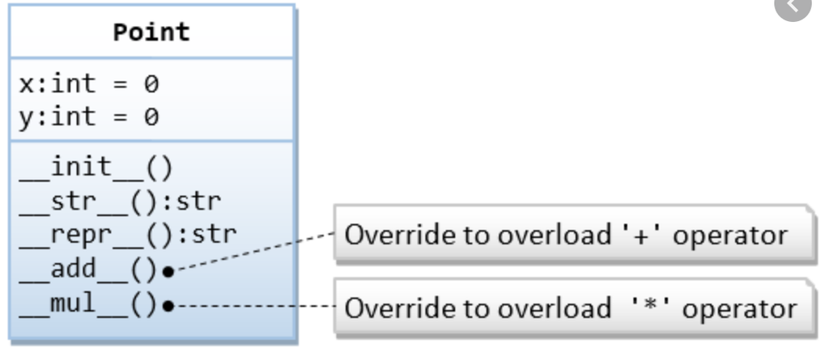

```python
Image("./이미지/클래스정의.png", width=500, height=500)
```

### 아무것도 하지 않는 클래스 정의

- 내부에 속성이나 메소드가 없는 클래스 정의한다.
- 하지만 항상 객체는 만들 수 있다

#### 클래스 예약어와 클래스 이름을 정의하고 pass 문장을 내부에 정의

```python
class Person :
    pass
```

#### 사용자 클래스의 최상위 클래스 확인

- 상속한 클래스는 **bases** 속성으로 확인할 수 있다.

```python
Person.__bases__
```

```
(object,)
```

## 4-3 상속관계 알아보기

- 상속한 클래스의 하위 클래스를 확인할 수 있다

```python
Image("./이미지/클래스상속.gif")
```

[output not shown]

```python
issubclass(Person, object)
```

```
True
```

#### 하나의 객체를 만들어서 변수에 할당한다

```python
p = Person()
```

### 어떤 클래스에 의해 객체가 생성되었는지를 확인

- 상속을 한 경우에는 상속한 클래스의 객체로 인식

```python
Image("./이미지/클래스와인스턴스관계.gif")
```

[output not shown]

```python
isinstance(p, Person)
```

```
True
```

```python
isinstance(p, object)
```

```
True
```

#### 변수를 조회하면 해당 클래스의 객체 레퍼런스를 출력한다.

```python
p
```

```
<__main__.Person at 0x1dd8b069e88>
```

#### 해당 객체를 생성한 클래스의 이름을 확인한다

```python
p.__class__.__name__
```

```
'Person'
```

### 클래스 상속 정의하기

```python
Image("./이미지/클래스상속2.gif", width=400, height=400)
```

[output not shown]

```python
class Parents(object) :
    pass
```

```python
Parents.__bases__
```

```
(object,)
```

```python
class Child(Parents) :
    pass
```

```python
Child.__bases__
```

```
(__main__.Parents,)
```

```python
issubclass(Child, Parents)
```

```
True
```

## 4-4 사용자 클래스로 객체 속성을 넣기

- 객체 내의 속성을 **init** 메소드 내부에 할당한다.

### 객체를 생성할 때는 초기화 함수에 정의한 매개변수에 해당하는 인자를 넣는다

```python
Image("./이미지/클래스초기화함수.gif", width=400, height=400)
```

[output not shown]

### 클래스 내부에 객체 의 속성을 정의한다.

- self 를 넣는 이유는 객체를 지정해서 그 내부에 속성을 생성한다는 뜻이다

```python
class Person :
    def __init__(self, name) :
        self.name = name
```

#### 객체를 만들때는 **init** 메소드의 self를 제외한 매개변수와 동일한 인자를 전달한다

```python
p_ = Person("클래스")
```

```python
p_
```

```
<__main__.Person at 0x1dd8b07ac48>
```

```python
p_.name
```

```
'클래스'
```

```python
p_.__dict__
```

```
{'name': '클래스'}
```

## 4-5 사용자 클래스의 메소드 넣기

- 객체가 사용할 수 있는 메소드를 정의할 때 첫번째 매개변수는 항상 self를 넣는다.
- 실제 객체가 self 자리에 들어와서 메소드를 처리한다.

### 클래스를 정의할 때 두 개의 속성과 두 개의 메소드를 정의한다.

- 메소드는 단순하게 조회만 할 수 있도록 내부에 매개변수는 self 만 넣는다

```python
class Person :
    def __init__(self, name, age) :
        self.name = name
        self.age = age

    def getName(self) :
        print(" getName 실행 ")
        return self.name

    def getAge(self) :
        print(" getAge 실행")
        return self.age
```

#### 객체를 생성한다

```python
p_1 = Person("이름", 24)
```

### 메소드 호출 방법

- 객체 다음에 점연산자와 메소드 이름을 작성한다.
- 메소드를 실행 연산자 안에 인자를 전달한다.
- self는 객체가 자동으로 세팅되므로 아무런 인자도 전달할 필요가 없다

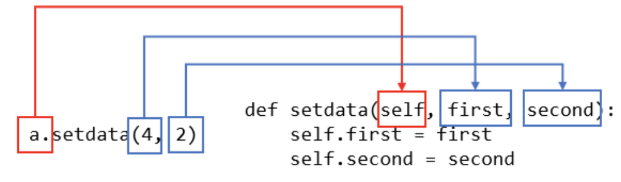

```python
Image("./이미지/메소드호출방법.png", width=500, height=300)
```

#### 두 개의 메소드를 실행한다

```python
p_1.getName()
```

```
 getName 실행
```

```
'이름'
```

```python
p_1.getAge()
```

```
 getAge 실행
```

```
24
```

#### 파이썬은 속성을 바로 사용할 수 있다

- 파이썬은 다른 프로그램 언어와 달리 객체의 속성을 바로 접근해서 사용할 수 있다.

```python
p_1.name
```

```
'이름'
```

```python
p_1.age
```

```
24
```